# Victim snippet input for LLM validation

Unlike the villain pipeline, victim snippets are not split into a main (ML-classifier) file plus a supplementary file. There is no victim-specific classifier output to draw a main pool from, so this notebook produces a single input file using the same corpus-reduction procedure as `villain_snippets_supplementary_input_LLM.csv`: relevance-filtered snippets restricted to hand-coded training articles, hand-coded texts excluded, actor mentions extracted with the NER actor codebook, and near-duplicate entity mentions canonicalized.

```python
# --- Prepare the victim Claude input (single file, no main/supplementary split) ---
import json
import os
import re

import pandas as pd

path = r"C:\Users\charlott\Dropbox (Personal)\Paper_Indonesia_Nickel\ln_training"
LABELED_PATH = r'C:\Users\charlott\Dropbox (Personal)\Paper_Indonesia_Nickel\ln_labeling\labeled_data_n154.xlsx'
SNIPPETS_PATH = os.path.join(path, 'snippets_qual_filter.csv')
CODEBOOK_PATH = os.path.join(path, 'ner_actor_codebook.json')
victim_output_path = os.path.join(path, 'victim_snippets_input_LLM.xlsx')

all_snippets = pd.read_csv(SNIPPETS_PATH)
hand_coded = pd.read_excel(LABELED_PATH, usecols=['Text', 'Source'])
training_ids = set(
    hand_coded['Source'].dropna().astype(str).str.replace(r'\.txt$', '', regex=True)
)

def normalize_text(value):
    return ' '.join(str(value).split()).casefold()

hand_coded_texts = {
    normalize_text(value) for value in hand_coded['Text'].dropna()
}
article_snippets = all_snippets[
    all_snippets['article_id'].astype(str).isin(training_ids)
].copy()
before_text_filter = len(article_snippets)
article_snippets = article_snippets[
    ~article_snippets['snippet'].map(normalize_text).isin(hand_coded_texts)
].copy()

# Match the full-input schema: one row per recognized actor mention.
with open(CODEBOOK_PATH, encoding='utf-8') as file:
    codebook = json.load(file)

def expand_terms(terms):
    expanded = []
    for raw_term in terms:
        for segment in str(raw_term).split(';'):
            for alternative in segment.split(' OR '):
                alternative = alternative.strip()
                if alternative:
                    expanded.append(alternative)
    return expanded

def make_pattern(term):
    term = term.lower()
    if term.endswith('y') and len(term) > 2 and term[-2] not in 'aeiou':
        return r'\b' + re.escape(term[:-1]) + r'(?:y|ies)\b'
    if re.search(r'(?:s|x|ch|sh|z)$', term):
        return r'\b' + re.escape(term) + r'(?:es)?\b'
    return r'\b' + re.escape(term) + r's?\b'

actor_patterns = {}
for record in codebook:
    category = record['actor_label']
    if category.startswith('*'):
        continue
    terms = [
        term for term in expand_terms(record['named_entities'])
        if term.lower() not in {'market', 'environment'}
    ]
    if terms:
        actor_patterns[category] = re.compile(
            '|'.join(make_pattern(term) for term in terms), re.IGNORECASE
        )

# Treat common references to the same real-world actor as one entity.
ACTOR_CANONICAL = {
    'widodo': 'Joko Widodo',
    'jokowi': 'Joko Widodo',
    'VALE': 'vale',
    'joko widodo': 'Joko Widodo',
    'imip': 'Indonesia Morowali Industrial Park',
    'pt imip': 'Indonesia Morowali Industrial Park',
    'indonesia morowali industrial park': 'Indonesia Morowali Industrial Park',
}

def canonicalize_actor(value):
    return ACTOR_CANONICAL.get(str(value).strip().casefold(), str(value).strip())

expanded_rows = []
for row in article_snippets.itertuples(index=False):
    text = str(row.snippet)
    for category, pattern in actor_patterns.items():
        for match in pattern.finditer(text):
            expanded_rows.append({
                'article_id': row.article_id,
                'actor_category': category,
                'matched_entity_text': canonicalize_actor(match.group(0)),
                'snippet_text': text,
            })

before_dedup = len(expanded_rows)
victim_df = pd.DataFrame(expanded_rows).drop_duplicates().reset_index(drop=True)
victim_df.insert(0, 'snippet_id', range(1, len(victim_df) + 1))
victim_df.to_excel(victim_output_path, index=False)

print(f"All relevance-filtered snippets: {len(all_snippets):,}")
print(f"Hand-coded article IDs: {len(training_ids):,}")
print(f"Rows before exact-text filter: {before_text_filter:,}")
print(f"Actor-mention rows before canonicalization/deduplication: {before_dedup:,}")
print(f"Exact duplicate rows removed after actor canonicalization: {before_dedup - len(victim_df):,}")
print(f"Victim input rows: {len(victim_df):,}")
print(f"Unique document IDs: {victim_df['article_id'].nunique():,}")
print(f"Saved to: {victim_output_path}")
```

```
All relevance-filtered snippets: 31,962
Hand-coded article IDs: 151
Rows before exact-text filter: 2,750
Actor-mention rows before canonicalization/deduplication: 3,108
Exact duplicate rows removed after actor canonicalization: 573
Victim input rows: 2,535
Unique document IDs: 138
Saved to: C:\Users\charlott\Dropbox (Personal)\Paper_Indonesia_Nickel\ln_training\victim_snippets_input_LLM.xlsx
```

## Supplementary file: newly recognized "Indonesian worker" mentions (hero + villain + victim)

The actor NER codebook's "Indonesian local community & workers" category previously had no entry for the literal phrase "Indonesian worker(s)" (only "Indonesian nationals", "local workers", "local miners", etc.), so snippets that name Indonesian victims only via that exact phrase - e.g. "Four Chinese and nine Indonesian workers died instantly" - produced no Indonesian-side actor mention at all, even though a Chinese-side mention (e.g. "Chinese nationals") was correctly detected in the same snippet. `ner_actor_codebook.json` was updated to add `Indonesian worker`, `Indonesian laborer`, `Indonesian labourer`, `Indonesian personnel` to that category.

Two matching passes, kept distinct via `match_type`:

- **`exact_phrase`**: the four codebook terms above, same literal-phrase matching as every other actor category.
- **`proximity`**: casualty reporting often elides the repeated noun in coordination - "Ten **Indonesian** and eight Chinese **workers** were killed" - or states the country name instead of the adjective, in either word order - "**workers** from China and **Indonesia**". No literal phrase covers these, so this pass instead looks for "indonesia(n/ns)" within 50 characters of "worker(s)", in either order, not crossing a sentence boundary. Spot-checked against a 25-row random sample of corpus-wide hits: the large majority are genuine Indonesian- worker mentions, with a handful of looser/ambiguous cases (e.g. "workers employed in Indonesia", which could in principle refer to non-Indonesian staff) - lower precision than `exact_phrase`, flagged as such rather than silently mixed in, so reviewers can weight it accordingly. Two of the harder examples that prompted this ("46 workers were injured, including 14 Chinese nationals"; "Forty-one workers ..., including 11 Chinese nationals") have no Indonesia/Indonesian word anywhere in the sentence - nationality is only implied by subtraction from a stated total, which neither pass can safely recover without inferring unstated facts.

This cell lives here but is **not victim-specific**: hero, victim, and villain's supplementary input all draw from the same 151-article hand-coded training pool, but villain's *main* input (`villain_snippets_full_input_LLM.csv`) is drawn separately from a much larger, 837-article ML-classified pool. To cover candidates for all three roles, this reruns both passes over the **full** relevance-filtered corpus (`snippets_qual_filter.csv`, all articles, only exact hand-coded training texts excluded - no training-article restriction), then checks each match against all four existing inputs (`heroe_snippets_input_LLM.xlsx`, `victim_snippets_input_LLM.xlsx`, `villain_snippets_full_input_LLM.csv`, `villain_snippets_supplementary_input_LLM.csv`) and flags (does not drop) rows already present there. Saved as `indonesian_workers_snippets_input_LLM.xlsx`.

```python
# --- Supplementary input across all three roles: actor mentions newly recognized by the
# Indonesian-worker codebook fix (see markdown above). Rebuilt from the full relevance-
# filtered corpus, not article_snippets above, since villain's main pool is not restricted
# to the training articles.
NEW_TERMS = ['Indonesian worker', 'Indonesian laborer', 'Indonesian labourer', 'Indonesian personnel']
NEW_CATEGORY = 'Indonesian local community & workers'
new_terms_output_path = os.path.join(path, 'indonesian_workers_snippets_input_LLM.xlsx')

full_corpus = pd.read_csv(SNIPPETS_PATH)
candidate_snippets = full_corpus[
    ~full_corpus['snippet'].map(normalize_text).isin(hand_coded_texts)
].copy()

# Pass 1: exact phrase, same mechanism as every other actor category.
exact_pattern = re.compile(
    '|'.join(make_pattern(term) for term in NEW_TERMS), re.IGNORECASE
)

# Pass 2: proximity. Catches coordination where the noun is elided ("Ten Indonesian and
# eight Chinese workers") or the country name is used instead of the adjective, in either
# order ("workers from China and Indonesia"). [^.]{0,50} bounds the gap to roughly one
# clause and never crosses a sentence-ending period.
proximity_forward = re.compile(r'\bindonesia(?:ns?|n)?\b[^.]{0,50}?\bworkers?\b', re.IGNORECASE)
proximity_backward = re.compile(r'\bworkers?\b[^.]{0,50}?\bindonesia(?:ns?|n)?\b', re.IGNORECASE)

matched_rows = []
for row in candidate_snippets.itertuples(index=False):
    text = str(row.snippet)
    for match in exact_pattern.finditer(text):
        matched_rows.append({
            'article_id': row.article_id, 'actor_category': NEW_CATEGORY,
            'matched_entity_text': canonicalize_actor(match.group(0)),
            'snippet_text': text, 'match_type': 'exact_phrase',
        })
    seen_spans = set()
    for pattern in (proximity_forward, proximity_backward):
        for match in pattern.finditer(text):
            if match.group(0) in seen_spans:
                continue
            seen_spans.add(match.group(0))
            matched_rows.append({
                'article_id': row.article_id, 'actor_category': NEW_CATEGORY,
                'matched_entity_text': canonicalize_actor(match.group(0)),
                'snippet_text': text, 'match_type': 'proximity',
            })

raw_matched_rows = len(matched_rows)
# Where both passes catch the same span (e.g. plain "Indonesian workers" trivially also
# satisfies the proximity regex with a zero-length gap), keep the exact_phrase row: sort it
# first, then dedup on everything except match_type so only one survives.
new_terms_df = (
    pd.DataFrame(matched_rows)
    .sort_values('match_type')  # 'exact_phrase' < 'proximity' alphabetically
    .drop_duplicates(subset=['article_id', 'actor_category', 'matched_entity_text', 'snippet_text'])
    .reset_index(drop=True)
)
rows_before_span_collapse = len(new_terms_df)

# A single snippet can trigger more than one span (e.g. an exact_phrase hit and a separate
# proximity hit, or two distinct proximity hits further apart in a longer snippet) - these
# are the same underlying actor mention for review purposes, so collapse to one row per
# (article_id, actor_category, snippet_text, match_type), keeping the longest/most
# informative matched_entity_text among the collapsed spans.
new_terms_df = (
    new_terms_df
    .assign(_span_len=new_terms_df['matched_entity_text'].str.len())
    .sort_values('_span_len', ascending=False)
    .drop_duplicates(subset=['article_id', 'actor_category', 'snippet_text', 'match_type'])
    .drop(columns='_span_len')
    .reset_index(drop=True)
)

# Flag (do not drop) rows already present in any of the three pipelines' existing input
# files: victim_snippets_input_LLM.xlsx was regenerated earlier today with the fixed
# codebook already in it (a side effect of testing, not deliberate), so it is no longer a
# trustworthy already-reviewed baseline - these rows were never in the version anyone
# actually reviewed. Kept in, with a flag, rather than silently excluded.
existing_frames = {
    'hero': pd.read_excel(os.path.join(path, 'heroe_snippets_input_LLM.xlsx')),
    'victim': victim_df,
    'villain_full': pd.read_csv(os.path.join(path, 'villain_snippets_full_input_LLM.csv')),
    'villain_supplementary': pd.read_csv(os.path.join(path, 'villain_snippets_supplementary_input_LLM.csv')),
}
KEY_COLS = ['article_id', 'actor_category', 'matched_entity_text', 'snippet_text']
existing_keys = set()
for frame in existing_frames.values():
    cols = [c for c in KEY_COLS if c in frame.columns]
    existing_keys |= set(frame[cols].apply(tuple, axis=1))

new_keys = new_terms_df[KEY_COLS].apply(tuple, axis=1)
already_present = new_keys.isin(existing_keys)
new_terms_df['already_in_existing_input'] = already_present.values
new_terms_df.insert(0, 'snippet_id', range(1, len(new_terms_df) + 1))

new_terms_df.to_excel(new_terms_output_path, index=False)

print(f"Full relevance-filtered corpus: {len(full_corpus):,}")
print(f"After excluding exact hand-coded training texts: {len(candidate_snippets):,}")
print(f"Raw matches, both passes, before dedup: {raw_matched_rows:,}")
print(f"After removing exact duplicate (article/entity/snippet) rows: {rows_before_span_collapse:,}")
print(f"After collapsing multiple spans within the same snippet to one row: {len(new_terms_df):,}")
print(new_terms_df['match_type'].value_counts().rename('rows by match_type').to_string())
print(f"Already present in an existing hero/victim/villain input file (flagged, not dropped): {already_present.sum()}")
print(f"Total rows kept (all): {len(new_terms_df):,}")
print(f"Unique articles: {new_terms_df['article_id'].nunique():,}")
print(f"Saved to: {new_terms_output_path}")
```

```
Full relevance-filtered corpus: 31,962
After excluding exact hand-coded training texts: 31,962
Raw matches, both passes, before dedup: 619
After removing exact duplicate (article/entity/snippet) rows: 465
After collapsing multiple spans within the same snippet to one row: 420
match_type
proximity       276
exact_phrase    144
Already present in an existing hero/victim/villain input file (flagged, not dropped): 32
Total rows kept (all): 420
Unique articles: 119
Saved to: C:\Users\charlott\Dropbox (Personal)\Paper_Indonesia_Nickel\ln_training\indonesian_workers_snippets_input_LLM.xlsx
```

### NOW READ IN THE FILE THAT XIAORAN MANUALLY VALIDATED

```
Label column: llm_target_victim | {'NO': 2395, 'YES': 107}
Changelog fields: {'llm_target_victim': 6}
Exact duplicates removed from validated set: 0

=== Model performance: Claude Sonnet 5 vs. manual validation (victim role) ===
                             Metric  Value
                 Snippet rows coded  2,502
             Model YES (first pass)    113
         Model UNCLEAR (first pass)      0
              Validated YES (final)    107
     YES confirmed (true positives)    107
         YES → NO (false positives)      6
                      UNCLEAR → YES      0
                       UNCLEAR → NO      0
                           NO → YES      0
    Precision of explicit YES calls  94.7%
  False-positive share of YES calls   5.3%
   Share of UNCLEAR resolved to YES    n/a
Agreement with validated (all rows) 99.76%

=== Rows changed by validation ===
 snippet_id              matched_entity_text                                      actor_category old_value new_value
        124 PT Virtue Dragon Nickel Industry                   Indonesian firms and local elites       YES        NO
        631                  Chinese workers                                      Chinese worker       YES        NO
        657                            Walhi                      Indonesian local civil society       YES        NO
        783     PT Gunbuster Nickel Industry                   Indonesian firms and local elites       YES        NO
        876                          Prabowo Indonesian government: central government/president       YES        NO
       1445                           Lygend                                  Chinese firms/SOEs       YES        NO

 already_in_existing_input
False    388
True      32
Name: count, dtype: int64
llm_target_victim
YES    229
NO     191
Name: count, dtype: int64
Additional rows: 420 → 388 (removed 32 flagged + 0 content duplicates)
Combined: 2,890 rows; victim = YES: 317
```

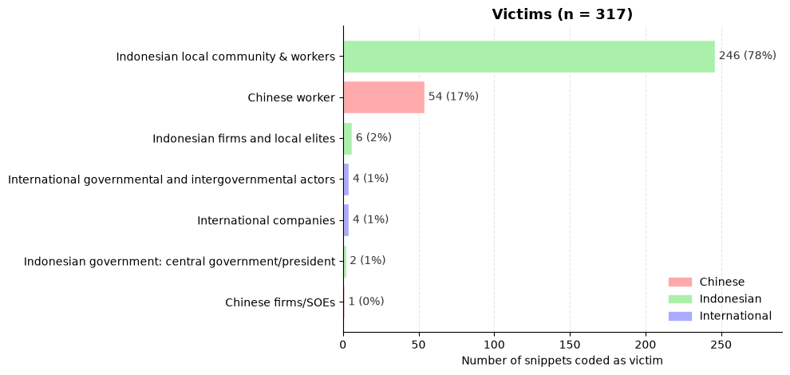

```python
import pandas as pd
import numpy as np
import matplotlib.pyplot as plt
from pathlib import Path

VICT_DIR = Path('victim_full_after_validation')              # relative to the notebook (ln_llm)
ADD_DIR  = Path('addition_Indonesian_workers_all_roles')

# ── 1. Load the validated dataset + changelog ────────────────────────────────
snip = pd.read_csv(VICT_DIR / 'victim_snippets_output_FINAL_validated.csv')
chg  = pd.read_csv(VICT_DIR / 'victim_dataset_validation_changelog.csv')

LABEL = next(c for c in snip.columns if c.startswith('llm_target_'))   # e.g. llm_target_victim
print('Label column:', LABEL, '|', snip[LABEL].value_counts(dropna=False).to_dict())
print('Changelog fields:', chg['field_changed'].value_counts().to_dict())   # check: only LABEL should matter

# ── 2. Reconstruct the model's original (pre-validation) labels ──────────────
snip['victim_validated'] = snip[LABEL].astype(str).str.strip().str.upper()
snip['victim_model']     = snip['victim_validated']

# keep real changes of the label column only ("confirmed, no change" rows have old == new)
changes = chg[(chg['old_value'] != chg['new_value']) &
              chg['field_changed'].astype(str).str.contains(LABEL)].copy()
snip = snip.set_index('snippet_id')
snip.loc[changes['snippet_id'], 'victim_model'] = changes['old_value'].astype(str).str.upper().values
snip = snip.reset_index()

# ── 3. Remove exact duplicates (same article + entity + text) ────────────────
def content_key(d):
    return (d['article_id'].astype(str) + '|' + d['matched_entity_text'].astype(str) + '|' +
            d['snippet_text'].astype(str).str.strip())

dups = content_key(snip).duplicated(keep='first')
print(f'Exact duplicates removed from validated set: {dups.sum():,}')
snip = snip[~dups].copy()

# ── 4. Performance summary (validated label = ground truth) ──────────────────
mod, fin = snip['victim_model'], snip['victim_validated']
n_yes, n_unc = (mod == 'YES').sum(), (mod == 'UNCLEAR').sum()
tp = ((mod == 'YES') & (fin == 'YES')).sum()
fp = ((mod == 'YES') & (fin == 'NO')).sum()
u_yes = ((mod == 'UNCLEAR') & (fin == 'YES')).sum()
u_no  = ((mod == 'UNCLEAR') & (fin == 'NO')).sum()
no_yes = ((mod == 'NO') & (fin == 'YES')).sum()

summary = pd.DataFrame({
    'Metric': ['Snippet rows coded', 'Model YES (first pass)', 'Model UNCLEAR (first pass)',
               'Validated YES (final)', 'YES confirmed (true positives)',
               'YES → NO (false positives)', 'UNCLEAR → YES', 'UNCLEAR → NO', 'NO → YES',
               'Precision of explicit YES calls', 'False-positive share of YES calls',
               'Share of UNCLEAR resolved to YES', 'Agreement with validated (all rows)'],
    'Value': [f'{len(snip):,}', n_yes, n_unc, (fin == 'YES').sum(), tp, fp, u_yes, u_no, no_yes,
              f'{tp / n_yes:.1%}', f'{fp / n_yes:.1%}',
              f'{u_yes / n_unc:.1%}' if n_unc else 'n/a', f'{(mod == fin).mean():.2%}'],
})
print('\n=== Model performance: Claude Sonnet 5 vs. manual validation (victim role) ===')
print(summary.to_string(index=False))

changed_rows = (changes[['snippet_id', 'old_value', 'new_value']]
                .merge(snip[['snippet_id', 'matched_entity_text', 'actor_category']],
                       on='snippet_id', how='left')
                [['snippet_id', 'matched_entity_text', 'actor_category', 'old_value', 'new_value']])
print('\n=== Rows changed by validation ===')
print(changed_rows.to_string(index=False))

# ── 5. Additional Indonesian-workers file ────────────────────────────────────
add = pd.read_csv(ADD_DIR / 'indonesian_workers_VICTIM.csv')
ADD_LABEL = next(c for c in add.columns if c.startswith('llm_target_'))
print('\n', add['already_in_existing_input'].value_counts(dropna=False))
print(add[ADD_LABEL].value_counts(dropna=False))

already = (add['already_in_existing_input'].astype(str).str.strip().str.lower()
           .isin(['true', 'yes', 'y', '1']))
add_new = add[~already].copy()
n0 = len(add_new)
add_new = add_new[~content_key(add_new).isin(set(content_key(snip)))]
add_new = add_new[~content_key(add_new).duplicated()]
print(f'Additional rows: {len(add):,} → {len(add_new):,} (removed {already.sum():,} flagged + '
      f'{n0 - len(add_new):,} content duplicates)')

# ── 6. Combine ───────────────────────────────────────────────────────────────
orig = snip.assign(victim_final=snip['victim_validated'])
new  = add_new.assign(victim_final=add_new[ADD_LABEL].astype(str).str.strip().str.upper())
shared = ['snippet_id', 'article_id', 'actor_category', 'matched_entity_text', 'snippet_text',
          'llm_relevant_problem', 'victim_final', 'llm_evidence', 'llm_reason']
combined = pd.concat([orig[shared], new[shared]], ignore_index=True)
print(f'Combined: {len(combined):,} rows; victim = YES: {(combined.victim_final == "YES").sum()}')

# ── 7. Bar chart: victim calls by actor category ─────────────────────────────
ACTOR_TO_GROUP = {
    'Chinese DFIs (banks)': 'Chinese', 'Chinese firms/SOEs': 'Chinese',
    'Chinese government': 'Chinese', 'Chinese worker': 'Chinese',
    'Indonesian government: central government/president': 'Indonesian',
    'Indonesian government: local government (provincial/regional officials)': 'Indonesian',
    'Indonesian firms and local elites': 'Indonesian',
    'Indonesian local civil society': 'Indonesian',
    'Indonesian local community & workers': 'Indonesian',
    'International governmental and intergovernmental actors': 'International',
    'International companies': 'International',
    'International NGOs/watchdog': 'International',
}
GROUP_COLORS = {'Chinese': '#FFAAAA', 'Indonesian': '#AAF0AA', 'International': '#AAAAFF'}

victims = combined[combined['victim_final'] == 'YES']
counts = victims['actor_category'].value_counts().sort_values()

fig, ax = plt.subplots(figsize=(10, 4.8))
bars = ax.barh(counts.index, counts.values,
               color=[GROUP_COLORS[ACTOR_TO_GROUP[a]] for a in counts.index], edgecolor='white')
for b, n in zip(bars, counts.values):
    ax.text(n + counts.max() * 0.01, b.get_y() + b.get_height() / 2, f'{n} ({n/counts.sum():.0%})',
            va='center', fontsize=10, color='#333333')
ax.set_xlabel('Number of snippets coded as victim')
ax.set_title(f'Victims (n = {counts.sum()})', fontsize=13, fontweight='bold')
ax.set_xlim(0, counts.max() * 1.18)
ax.spines[['top', 'right']].set_visible(False)
ax.grid(axis='x', linestyle='--', alpha=0.3); ax.set_axisbelow(True)
ax.legend([plt.Rectangle((0, 0), 1, 1, color=c) for c in GROUP_COLORS.values()],
          GROUP_COLORS.keys(), frameon=False, loc='lower right')
plt.tight_layout()
plt.savefig(VICT_DIR / 'victim_by_actor_category_combined.png', dpi=150,
            bbox_inches='tight', facecolor='white')
plt.show()

# combined.to_csv(VICT_DIR / 'victim_combined_all.csv', index=False, encoding='utf-8-sig')
```